# python project week - 4 (part-2)

# 1.Import required libraries and read the dataset.

```python
import pandas as pd
import numpy as np
import matplotlib.pyplot as plt
import seaborn as sns
import warnings
warnings.filterwarnings("ignore")
from PIL import Image
```

```python
data=pd.read_csv("honeyproduction.csv")
```

# 2. Check the first few samples, shape, info of the data and try to familiarize yourself with different features.

```python
data.head(10)
```

|  | state | numcol | yieldpercol | totalprod | stocks | priceperlb | prodvalue | year |
| --- | --- | --- | --- | --- | --- | --- | --- | --- |
| 0 | AL | 16000.0 | 71 | 1136000.0 | 159000.0 | 0.72 | 818000.0 | 1998 |
| 1 | AZ | 55000.0 | 60 | 3300000.0 | 1485000.0 | 0.64 | 2112000.0 | 1998 |
| 2 | AR | 53000.0 | 65 | 3445000.0 | 1688000.0 | 0.59 | 2033000.0 | 1998 |
| 3 | CA | 450000.0 | 83 | 37350000.0 | 12326000.0 | 0.62 | 23157000.0 | 1998 |
| 4 | CO | 27000.0 | 72 | 1944000.0 | 1594000.0 | 0.70 | 1361000.0 | 1998 |
| 5 | FL | 230000.0 | 98 | 22540000.0 | 4508000.0 | 0.64 | 14426000.0 | 1998 |
| 6 | GA | 75000.0 | 56 | 4200000.0 | 307000.0 | 0.69 | 2898000.0 | 1998 |
| 7 | HI | 8000.0 | 118 | 944000.0 | 66000.0 | 0.77 | 727000.0 | 1998 |
| 8 | ID | 120000.0 | 50 | 6000000.0 | 2220000.0 | 0.65 | 3900000.0 | 1998 |
| 9 | IL | 9000.0 | 71 | 639000.0 | 204000.0 | 1.19 | 760000.0 | 1998 |

```python
data.tail(10)
```

|  | state | numcol | yieldpercol | totalprod | stocks | priceperlb | prodvalue | year |
| --- | --- | --- | --- | --- | --- | --- | --- | --- |
| 616 | SD | 260000.0 | 63 | 16380000.0 | 3604000.0 | 1.95 | 31941000.0 | 2012 |
| 617 | TN | 6000.0 | 61 | 366000.0 | 59000.0 | 2.93 | 1072000.0 | 2012 |
| 618 | TX | 92000.0 | 52 | 4784000.0 | 718000.0 | 2.00 | 9568000.0 | 2012 |
| 619 | UT | 25000.0 | 38 | 950000.0 | 209000.0 | 1.87 | 1777000.0 | 2012 |
| 620 | VT | 4000.0 | 60 | 240000.0 | 53000.0 | 2.39 | 574000.0 | 2012 |
| 621 | VA | 4000.0 | 41 | 164000.0 | 23000.0 | 3.77 | 618000.0 | 2012 |
| 622 | WA | 62000.0 | 41 | 2542000.0 | 1017000.0 | 2.38 | 6050000.0 | 2012 |
| 623 | WV | 6000.0 | 48 | 288000.0 | 95000.0 | 2.91 | 838000.0 | 2012 |
| 624 | WI | 60000.0 | 69 | 4140000.0 | 1863000.0 | 2.05 | 8487000.0 | 2012 |
| 625 | WY | 50000.0 | 51 | 2550000.0 | 459000.0 | 1.87 | 4769000.0 | 2012 |

```python
data.info()
```

```
<class 'pandas.core.frame.DataFrame'>
RangeIndex: 626 entries, 0 to 625
Data columns (total 8 columns):
 #   Column       Non-Null Count  Dtype
---  ------       --------------  -----
 0   state        626 non-null    object
 1   numcol       626 non-null    float64
 2   yieldpercol  626 non-null    int64
 3   totalprod    626 non-null    float64
 4   stocks       626 non-null    float64
 5   priceperlb   626 non-null    float64
 6   prodvalue    626 non-null    float64
 7   year         626 non-null    int64
dtypes: float64(5), int64(2), object(1)
memory usage: 39.3+ KB
```

```python
data.shape
```

```
(626, 8)
```

```python
data.describe()
```

|  | numcol | yieldpercol | totalprod | stocks | priceperlb | prodvalue | year |
| --- | --- | --- | --- | --- | --- | --- | --- |
| count | 626.000000 | 626.000000 | 6.260000e+02 | 6.260000e+02 | 626.000000 | 6.260000e+02 | 626.000000 |
| mean | 60284.345048 | 62.009585 | 4.169086e+06 | 1.318859e+06 | 1.409569 | 4.715741e+06 | 2004.864217 |
| std | 91077.087231 | 19.458754 | 6.883847e+06 | 2.272964e+06 | 0.638599 | 7.976110e+06 | 4.317306 |
| min | 2000.000000 | 19.000000 | 8.400000e+04 | 8.000000e+03 | 0.490000 | 1.620000e+05 | 1998.000000 |
| 25% | 9000.000000 | 48.000000 | 4.750000e+05 | 1.430000e+05 | 0.932500 | 7.592500e+05 | 2001.000000 |
| 50% | 26000.000000 | 60.000000 | 1.533000e+06 | 4.395000e+05 | 1.360000 | 1.841500e+06 | 2005.000000 |
| 75% | 63750.000000 | 74.000000 | 4.175250e+06 | 1.489500e+06 | 1.680000 | 4.703250e+06 | 2009.000000 |
| max | 510000.000000 | 136.000000 | 4.641000e+07 | 1.380000e+07 | 4.150000 | 6.961500e+07 | 2012.000000 |

```python
data.nunique()
```

```
state           44
numcol         148
yieldpercol     95
totalprod      517
stocks         500
priceperlb     210
prodvalue      589
year            15
dtype: int64
```

```python
data.columns
```

```
Index(['state', 'numcol', 'yieldpercol', 'totalprod', 'stocks', 'priceperlb',
       'prodvalue', 'year'],
      dtype='object')
```

# 3. Display the percentage distribution of the data in each year using the pie chart.

```python
data.year.value_counts(sort=False)
```

```
1998    43
1999    43
2000    43
2001    44
2002    44
2003    44
2004    41
2005    41
2006    41
2007    41
2008    41
2009    40
2010    40
2011    40
2012    40
Name: year, dtype: int64
```

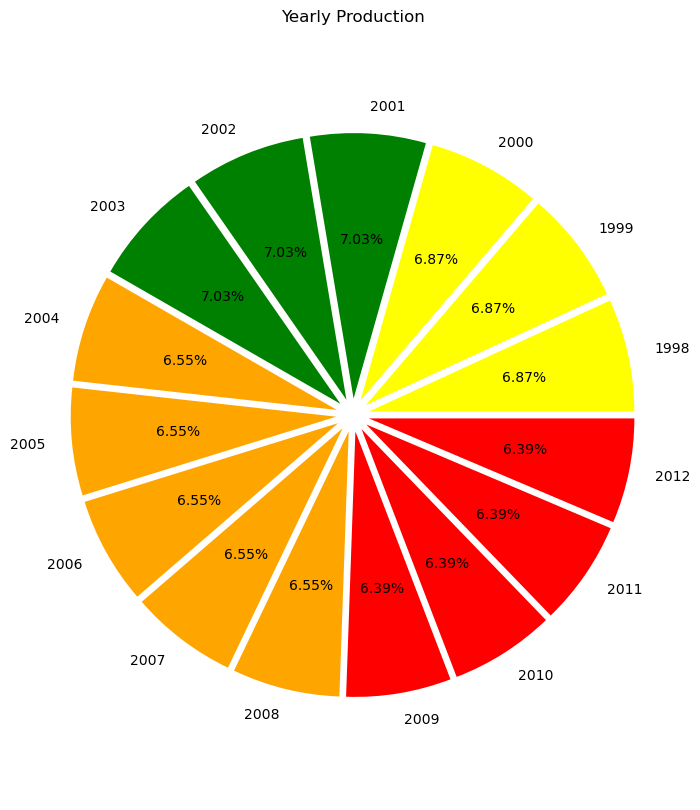

```python
plt.figure(figsize=(8,10))
my_colors=["yellow","yellow","yellow","green","green","green","orange","orange","orange","orange","orange","red","red","red","red"]
my_labels="1998","1999","2000","2001","2002","2003","2004","2005","2006","2007","2008","2009","2010","2011","2012"
my_explode=(0.05,0.05,0.05,0.05,0.05,0.05,0.05,0.05,0.05,0.05,0.05,0.05,0.05,0.05,0.05)
plt.pie(data.year.value_counts(sort=False),labels=my_labels,explode=my_explode,autopct='%.2f%%',radius=0.8,colors=my_colors)
plt.title('Yearly Production')
plt.axis('equal')
plt.show()
```

# 4. Plot and Understand the distribution of the variable "price per lb" using displot, and write your findings.

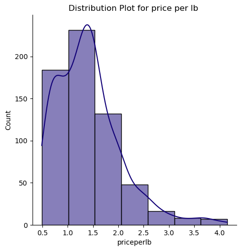

```python
sns.displot(data["priceperlb"],bins=7,color="#107",kde=True)
plt.title("Distribution Plot for price per lb ")
plt.show()
```

- It is positively skewed.
- Most of the price that is priceperlb ranges between 0.5 and 2.0

# 5.Plot and understand the relationship between the variables 'numcol' and 'prodval' through scatterplot, and wite your findings

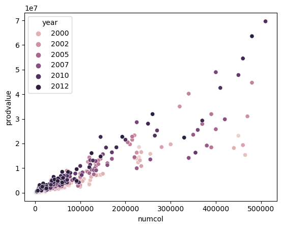

```python
sns.scatterplot(x=data["numcol"],y=data["prodvalue"],hue=data["year"],data=data,color=["red"])
plt.show()
```

It shows a positive relationship.When the numcol increases, prodvalue is also linearly increasing.

# 6. Plot and understand the relationship between categorical variable 'year' and a numerical variable 'prodvalue' through boxplot, and write your findings.

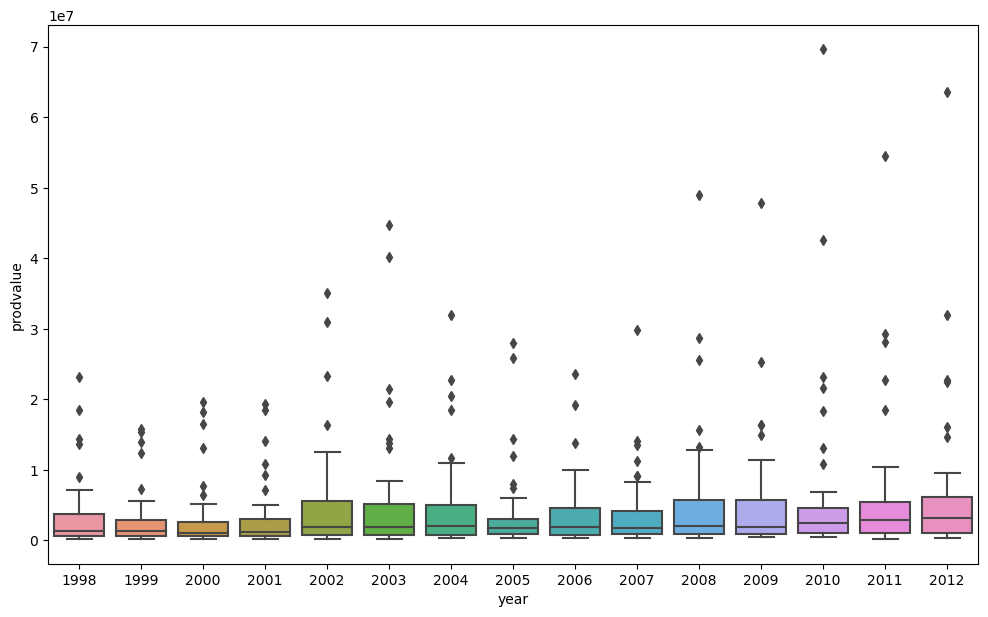

```python
plt.figure(figsize=(12,7))
sns.boxplot(data=data,x=data["year"],y=data["prodvalue"],width=0.8)
plt.show()
```

In every year there is a specific amount of honey is produced within a specific range..

# 7. Visualize and understand the relationship between the multiple pairs of variables throughout different years using pairplot and add your inferences. (use columns 'numcol', 'yield percol', 'total prod', 'prodvalue','year')

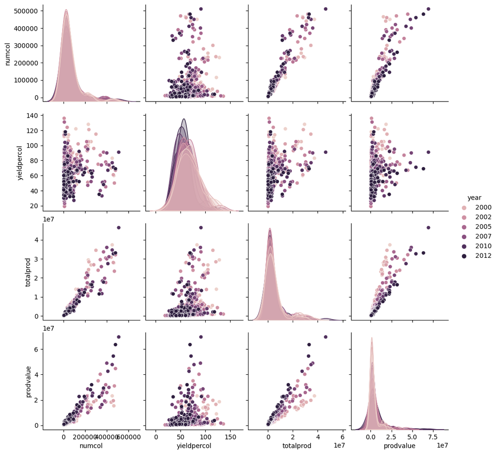

```python
sns.pairplot(data=data, hue='year', vars=['numcol', 'yieldpercol','totalprod','prodvalue'])
plt.show()
```

- There is a relationship between totalprod and prodvalue.
- There is a relationship between prodvalue and numcol.
- There is a relationship between totalprod and numcol.

# 8. Display the correlation values using a plot and add your inferences. (use columns 'numcol', 'yieldpercol','totalprod', 'stocks', 'priceperlb', 'prodvalue')

```python
data.corr()
```

|  | numcol | yieldpercol | totalprod | stocks | priceperlb | prodvalue | year |
| --- | --- | --- | --- | --- | --- | --- | --- |
| numcol | 1.000000 | 0.243515 | 0.953594 | 0.825929 | -0.232701 | 0.912796 | 0.008709 |
| yieldpercol | 0.243515 | 1.000000 | 0.396252 | 0.367812 | -0.358646 | 0.278977 | -0.232092 |
| totalprod | 0.953594 | 0.396252 | 1.000000 | 0.878830 | -0.264499 | 0.907236 | -0.055556 |
| stocks | 0.825929 | 0.367812 | 0.878830 | 1.000000 | -0.305867 | 0.728560 | -0.119602 |
| priceperlb | -0.232701 | -0.358646 | -0.264499 | -0.305867 | 1.000000 | -0.089567 | 0.693984 |
| prodvalue | 0.912796 | 0.278977 | 0.907236 | 0.728560 | -0.089567 | 1.000000 | 0.139451 |
| year | 0.008709 | -0.232092 | -0.055556 | -0.119602 | 0.693984 | 0.139451 | 1.000000 |

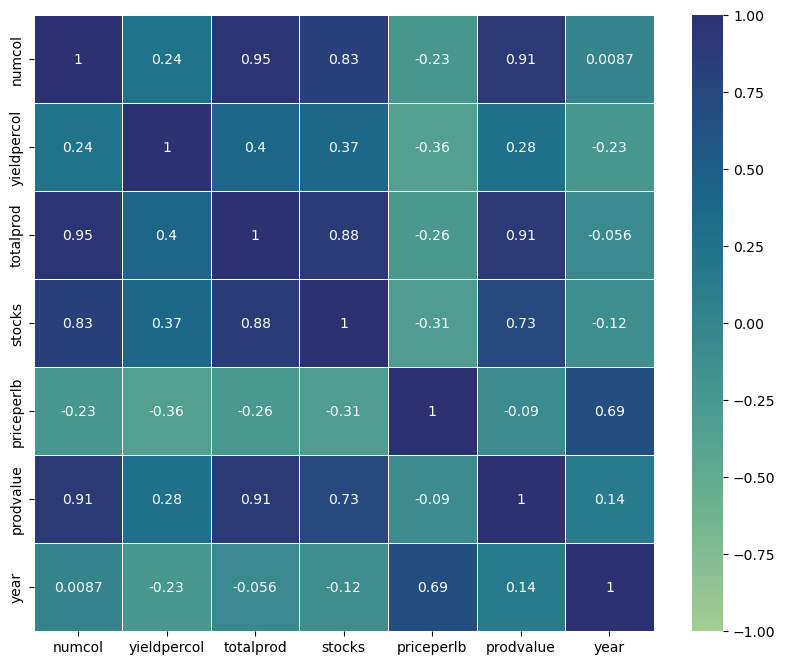

```python
plt.figure(figsize=(10,8))
sns.heatmap(data=data.corr(),annot=True,vmin=-1,vmax=1,cmap="crest",linewidth=0.5,center=0,linecolor="white")
plt.show()
```

- Numcol have a high positive correlation with totalprod, stocks and prodvalue.
- There is a negative correlation between yieldpercol and priceperlb.
- There is a zero correlation between year and numcol.